# Project: Investigate a Dataset - [No_Show_Appointments]

- Introduction
- Data Wrangling
- Exploratory Data Analysis
- Conclusions

## Introduction

### Question(s) for Analysis

Two questions will be answered in the course of investigating this dataset:

**Question 1:** What age group show up for their appointment mostly?

**Question 2:** Do patients under the Brasiilian scholarship show up for their appointment more than those who are not?

```python
# import all packages to be used

import pandas as pd
import numpy as np
import matplotlib.pyplot as plt
import seaborn as sns
% matplotlib inline
```

```python
# Upgrade pandas to use dataframe.explode() function.
!pip install --upgrade pandas==0.25.0
```

[output not shown]

## Data Wrangling

### General Properties

```python
# Load data and print out a few lines.
df = pd.read_csv('no_show_appointments.csv')
df.head()
```

|  | PatientId | AppointmentID | Gender | ScheduledDay | AppointmentDay | Age | Neighbourhood | Scholarship | Hipertension | Diabetes | Alcoholism | Handcap | SMS_received | No-show |
| --- | --- | --- | --- | --- | --- | --- | --- | --- | --- | --- | --- | --- | --- | --- |
| 0 | 2.987250e+13 | 5642903 | F | 2016-04-29T18:38:08Z | 2016-04-29T00:00:00Z | 62 | JARDIM DA PENHA | 0 | 1 | 0 | 0 | 0 | 0 | No |
| 1 | 5.589978e+14 | 5642503 | M | 2016-04-29T16:08:27Z | 2016-04-29T00:00:00Z | 56 | JARDIM DA PENHA | 0 | 0 | 0 | 0 | 0 | 0 | No |
| 2 | 4.262962e+12 | 5642549 | F | 2016-04-29T16:19:04Z | 2016-04-29T00:00:00Z | 62 | MATA DA PRAIA | 0 | 0 | 0 | 0 | 0 | 0 | No |
| 3 | 8.679512e+11 | 5642828 | F | 2016-04-29T17:29:31Z | 2016-04-29T00:00:00Z | 8 | PONTAL DE CAMBURI | 0 | 0 | 0 | 0 | 0 | 0 | No |
| 4 | 8.841186e+12 | 5642494 | F | 2016-04-29T16:07:23Z | 2016-04-29T00:00:00Z | 56 | JARDIM DA PENHA | 0 | 1 | 1 | 0 | 0 | 0 | No |

```python
# Check for data types and look for instances of missing or possibly errant data.
df.info()
```

```
<class 'pandas.core.frame.DataFrame'>
RangeIndex: 110527 entries, 0 to 110526
Data columns (total 14 columns):
PatientId         110527 non-null float64
AppointmentID     110527 non-null int64
Gender            110527 non-null object
ScheduledDay      110527 non-null object
AppointmentDay    110527 non-null object
Age               110527 non-null int64
Neighbourhood     110527 non-null object
Scholarship       110527 non-null int64
Hipertension      110527 non-null int64
Diabetes          110527 non-null int64
Alcoholism        110527 non-null int64
Handcap           110527 non-null int64
SMS_received      110527 non-null int64
No-show           110527 non-null object
dtypes: float64(1), int64(8), object(5)
memory usage: 11.8+ MB
```

# Data Cleaning

### Change column names

```python
# change column names
df = df.rename(columns = {'No-show':'No_show', 'Hipertension': 'Hypertension', 'Handcap': 'Handicap', 'PatientId': 'PatientID'})
df
```

|  | PatientID | AppointmentID | Gender | ScheduledDay | AppointmentDay | Age | Neighbourhood | Scholarship | Hypertension | Diabetes | Alcoholism | Handicap | SMS_received | No_show |
| --- | --- | --- | --- | --- | --- | --- | --- | --- | --- | --- | --- | --- | --- | --- |
| 0 | 2.987250e+13 | 5642903 | F | 2016-04-29T18:38:08Z | 2016-04-29T00:00:00Z | 62 | JARDIM DA PENHA | 0 | 1 | 0 | 0 | 0 | 0 | No |
| 1 | 5.589978e+14 | 5642503 | M | 2016-04-29T16:08:27Z | 2016-04-29T00:00:00Z | 56 | JARDIM DA PENHA | 0 | 0 | 0 | 0 | 0 | 0 | No |
| 2 | 4.262962e+12 | 5642549 | F | 2016-04-29T16:19:04Z | 2016-04-29T00:00:00Z | 62 | MATA DA PRAIA | 0 | 0 | 0 | 0 | 0 | 0 | No |
| 3 | 8.679512e+11 | 5642828 | F | 2016-04-29T17:29:31Z | 2016-04-29T00:00:00Z | 8 | PONTAL DE CAMBURI | 0 | 0 | 0 | 0 | 0 | 0 | No |
| 4 | 8.841186e+12 | 5642494 | F | 2016-04-29T16:07:23Z | 2016-04-29T00:00:00Z | 56 | JARDIM DA PENHA | 0 | 1 | 1 | 0 | 0 | 0 | No |
| 5 | 9.598513e+13 | 5626772 | F | 2016-04-27T08:36:51Z | 2016-04-29T00:00:00Z | 76 | REPÚBLICA | 0 | 1 | 0 | 0 | 0 | 0 | No |
| 6 | 7.336882e+14 | 5630279 | F | 2016-04-27T15:05:12Z | 2016-04-29T00:00:00Z | 23 | GOIABEIRAS | 0 | 0 | 0 | 0 | 0 | 0 | Yes |
| 7 | 3.449833e+12 | 5630575 | F | 2016-04-27T15:39:58Z | 2016-04-29T00:00:00Z | 39 | GOIABEIRAS | 0 | 0 | 0 | 0 | 0 | 0 | Yes |
| 8 | 5.639473e+13 | 5638447 | F | 2016-04-29T08:02:16Z | 2016-04-29T00:00:00Z | 21 | ANDORINHAS | 0 | 0 | 0 | 0 | 0 | 0 | No |
| 9 | 7.812456e+13 | 5629123 | F | 2016-04-27T12:48:25Z | 2016-04-29T00:00:00Z | 19 | CONQUISTA | 0 | 0 | 0 | 0 | 0 | 0 | No |
| 10 | 7.345362e+14 | 5630213 | F | 2016-04-27T14:58:11Z | 2016-04-29T00:00:00Z | 30 | NOVA PALESTINA | 0 | 0 | 0 | 0 | 0 | 0 | No |
| 11 | 7.542951e+12 | 5620163 | M | 2016-04-26T08:44:12Z | 2016-04-29T00:00:00Z | 29 | NOVA PALESTINA | 0 | 0 | 0 | 0 | 0 | 1 | Yes |
| 12 | 5.666548e+14 | 5634718 | F | 2016-04-28T11:33:51Z | 2016-04-29T00:00:00Z | 22 | NOVA PALESTINA | 1 | 0 | 0 | 0 | 0 | 0 | No |
| 13 | 9.113946e+14 | 5636249 | M | 2016-04-28T14:52:07Z | 2016-04-29T00:00:00Z | 28 | NOVA PALESTINA | 0 | 0 | 0 | 0 | 0 | 0 | No |
| 14 | 9.988472e+13 | 5633951 | F | 2016-04-28T10:06:24Z | 2016-04-29T00:00:00Z | 54 | NOVA PALESTINA | 0 | 0 | 0 | 0 | 0 | 0 | No |
| 15 | 9.994839e+10 | 5620206 | F | 2016-04-26T08:47:27Z | 2016-04-29T00:00:00Z | 15 | NOVA PALESTINA | 0 | 0 | 0 | 0 | 0 | 1 | No |
| 16 | 8.457439e+13 | 5633121 | M | 2016-04-28T08:51:47Z | 2016-04-29T00:00:00Z | 50 | NOVA PALESTINA | 0 | 0 | 0 | 0 | 0 | 0 | No |
| 17 | 1.479497e+13 | 5633460 | F | 2016-04-28T09:28:57Z | 2016-04-29T00:00:00Z | 40 | CONQUISTA | 1 | 0 | 0 | 0 | 0 | 0 | Yes |
| 18 | 1.713538e+13 | 5621836 | F | 2016-04-26T10:54:18Z | 2016-04-29T00:00:00Z | 30 | NOVA PALESTINA | 1 | 0 | 0 | 0 | 0 | 1 | No |
| 19 | 7.223289e+12 | 5640433 | F | 2016-04-29T10:43:14Z | 2016-04-29T00:00:00Z | 46 | DA PENHA | 0 | 0 | 0 | 0 | 0 | 0 | No |
| 20 | 6.222575e+14 | 5626083 | F | 2016-04-27T07:51:14Z | 2016-04-29T00:00:00Z | 30 | NOVA PALESTINA | 0 | 0 | 0 | 0 | 0 | 0 | Yes |
| 21 | 1.215484e+13 | 5628338 | F | 2016-04-27T10:50:45Z | 2016-04-29T00:00:00Z | 4 | CONQUISTA | 0 | 0 | 0 | 0 | 0 | 0 | Yes |
| 22 | 8.632298e+14 | 5616091 | M | 2016-04-25T13:29:16Z | 2016-04-29T00:00:00Z | 13 | CONQUISTA | 0 | 0 | 0 | 0 | 0 | 1 | Yes |
| 23 | 2.137540e+14 | 5634142 | F | 2016-04-28T10:27:05Z | 2016-04-29T00:00:00Z | 46 | CONQUISTA | 0 | 0 | 0 | 0 | 0 | 0 | No |
| 24 | 8.734858e+12 | 5641780 | F | 2016-04-29T14:19:19Z | 2016-04-29T00:00:00Z | 65 | TABUAZEIRO | 0 | 0 | 0 | 0 | 0 | 0 | No |
| 25 | 5.819370e+12 | 5624020 | M | 2016-04-26T15:04:17Z | 2016-04-29T00:00:00Z | 46 | CONQUISTA | 0 | 1 | 0 | 0 | 0 | 1 | No |
| 26 | 2.578785e+10 | 5641781 | F | 2016-04-29T14:19:42Z | 2016-04-29T00:00:00Z | 45 | BENTO FERREIRA | 0 | 1 | 0 | 0 | 0 | 0 | No |
| 27 | 1.215484e+13 | 5628345 | F | 2016-04-27T10:51:45Z | 2016-04-29T00:00:00Z | 4 | CONQUISTA | 0 | 0 | 0 | 0 | 0 | 0 | No |
| 28 | 5.926172e+12 | 5642400 | M | 2016-04-29T15:48:02Z | 2016-04-29T00:00:00Z | 51 | SÃO PEDRO | 0 | 0 | 0 | 0 | 0 | 0 | No |
| 29 | 1.225776e+12 | 5642186 | F | 2016-04-29T15:16:29Z | 2016-04-29T00:00:00Z | 32 | SANTA MARTHA | 0 | 0 | 0 | 0 | 0 | 0 | No |
| ... | ... | ... | ... | ... | ... | ... | ... | ... | ... | ... | ... | ... | ... | ... |
| 110497 | 7.935892e+14 | 5757745 | M | 2016-06-01T09:46:33Z | 2016-06-01T00:00:00Z | 76 | MARIA ORTIZ | 0 | 0 | 0 | 0 | 0 | 0 | No |
| 110498 | 9.433654e+13 | 5787655 | F | 2016-06-08T10:21:14Z | 2016-06-08T00:00:00Z | 59 | MARIA ORTIZ | 0 | 0 | 0 | 0 | 0 | 0 | No |
| 110499 | 8.219692e+14 | 5757697 | F | 2016-06-01T09:42:56Z | 2016-06-01T00:00:00Z | 66 | MARIA ORTIZ | 0 | 1 | 1 | 0 | 0 | 0 | No |
| 110500 | 4.434384e+14 | 5787233 | F | 2016-06-08T09:35:13Z | 2016-06-08T00:00:00Z | 59 | MARIA ORTIZ | 0 | 0 | 0 | 0 | 0 | 0 | No |
| 110501 | 4.544252e+11 | 5758133 | M | 2016-06-01T10:19:12Z | 2016-06-01T00:00:00Z | 44 | MARIA ORTIZ | 0 | 0 | 0 | 0 | 0 | 0 | No |
| 110502 | 7.316229e+14 | 5787937 | F | 2016-06-08T10:50:42Z | 2016-06-08T00:00:00Z | 22 | GOIABEIRAS | 0 | 0 | 0 | 0 | 0 | 0 | No |
| 110503 | 2.362182e+13 | 5759473 | F | 2016-06-01T13:00:36Z | 2016-06-01T00:00:00Z | 64 | SOLON BORGES | 0 | 0 | 0 | 0 | 0 | 0 | No |
| 110504 | 9.947983e+12 | 5788052 | F | 2016-06-08T11:06:21Z | 2016-06-08T00:00:00Z | 4 | MARIA ORTIZ | 0 | 0 | 0 | 0 | 0 | 0 | No |
| 110505 | 5.667344e+13 | 5758455 | F | 2016-06-01T10:45:50Z | 2016-06-01T00:00:00Z | 55 | MARIA ORTIZ | 0 | 0 | 0 | 0 | 0 | 0 | No |
| 110506 | 8.973883e+11 | 5758779 | M | 2016-06-01T11:09:20Z | 2016-06-01T00:00:00Z | 5 | MARIA ORTIZ | 0 | 0 | 0 | 0 | 0 | 0 | No |
| 110507 | 4.769462e+14 | 5786918 | F | 2016-06-08T09:04:18Z | 2016-06-08T00:00:00Z | 0 | MARIA ORTIZ | 0 | 0 | 0 | 0 | 0 | 0 | No |
| 110508 | 9.433654e+13 | 5757656 | F | 2016-06-01T09:41:00Z | 2016-06-01T00:00:00Z | 59 | MARIA ORTIZ | 0 | 0 | 0 | 0 | 0 | 0 | No |
| 110509 | 4.952968e+14 | 5786750 | M | 2016-06-08T08:50:51Z | 2016-06-08T00:00:00Z | 33 | MARIA ORTIZ | 0 | 0 | 0 | 0 | 0 | 0 | No |
| 110510 | 2.362182e+13 | 5757587 | F | 2016-06-01T09:35:48Z | 2016-06-01T00:00:00Z | 64 | SOLON BORGES | 0 | 0 | 0 | 0 | 0 | 0 | No |
| 110511 | 8.235996e+11 | 5786742 | F | 2016-06-08T08:50:20Z | 2016-06-08T00:00:00Z | 14 | MARIA ORTIZ | 0 | 0 | 0 | 0 | 0 | 0 | No |
| 110512 | 9.876246e+13 | 5786368 | F | 2016-06-08T08:20:01Z | 2016-06-08T00:00:00Z | 41 | MARIA ORTIZ | 0 | 0 | 0 | 0 | 0 | 0 | No |
| 110513 | 8.674778e+13 | 5785964 | M | 2016-06-08T07:52:55Z | 2016-06-08T00:00:00Z | 2 | ANTÔNIO HONÓRIO | 0 | 0 | 0 | 0 | 0 | 0 | No |
| 110514 | 2.695685e+12 | 5786567 | F | 2016-06-08T08:35:31Z | 2016-06-08T00:00:00Z | 58 | MARIA ORTIZ | 0 | 0 | 0 | 0 | 0 | 0 | No |
| 110515 | 6.456342e+14 | 5778621 | M | 2016-06-06T15:58:05Z | 2016-06-08T00:00:00Z | 33 | MARIA ORTIZ | 0 | 1 | 0 | 0 | 0 | 0 | Yes |
| 110516 | 6.923772e+13 | 5780205 | F | 2016-06-07T07:45:16Z | 2016-06-08T00:00:00Z | 37 | MARIA ORTIZ | 0 | 0 | 0 | 0 | 0 | 0 | Yes |
| 110517 | 5.574942e+12 | 5780122 | F | 2016-06-07T07:38:34Z | 2016-06-07T00:00:00Z | 19 | MARIA ORTIZ | 0 | 0 | 0 | 0 | 0 | 0 | No |
| 110518 | 7.263315e+13 | 5630375 | F | 2016-04-27T15:15:06Z | 2016-06-07T00:00:00Z | 50 | MARIA ORTIZ | 0 | 0 | 0 | 0 | 0 | 1 | No |
| 110519 | 6.542388e+13 | 5630447 | F | 2016-04-27T15:23:14Z | 2016-06-07T00:00:00Z | 22 | MARIA ORTIZ | 0 | 0 | 0 | 0 | 0 | 1 | No |
| 110520 | 9.969977e+14 | 5650534 | F | 2016-05-03T07:51:47Z | 2016-06-07T00:00:00Z | 42 | MARIA ORTIZ | 0 | 0 | 0 | 0 | 0 | 1 | No |
| 110521 | 3.635534e+13 | 5651072 | F | 2016-05-03T08:23:40Z | 2016-06-07T00:00:00Z | 53 | MARIA ORTIZ | 0 | 0 | 0 | 0 | 0 | 1 | No |
| 110522 | 2.572134e+12 | 5651768 | F | 2016-05-03T09:15:35Z | 2016-06-07T00:00:00Z | 56 | MARIA ORTIZ | 0 | 0 | 0 | 0 | 0 | 1 | No |
| 110523 | 3.596266e+12 | 5650093 | F | 2016-05-03T07:27:33Z | 2016-06-07T00:00:00Z | 51 | MARIA ORTIZ | 0 | 0 | 0 | 0 | 0 | 1 | No |
| 110524 | 1.557663e+13 | 5630692 | F | 2016-04-27T16:03:52Z | 2016-06-07T00:00:00Z | 21 | MARIA ORTIZ | 0 | 0 | 0 | 0 | 0 | 1 | No |
| 110525 | 9.213493e+13 | 5630323 | F | 2016-04-27T15:09:23Z | 2016-06-07T00:00:00Z | 38 | MARIA ORTIZ | 0 | 0 | 0 | 0 | 0 | 1 | No |
| 110526 | 3.775115e+14 | 5629448 | F | 2016-04-27T13:30:56Z | 2016-06-07T00:00:00Z | 54 | MARIA ORTIZ | 0 | 0 | 0 | 0 | 0 | 1 | No |

110527 rows × 14 columns

Columns names like *Hipertension* and *Handcap* that were wrongly spelt were corrected. *No-show* was renamed to _No*show* to maintain the consistency of the usage of underscore("_").

### Convert to appropriate datatypes

1. Convert PatientID, AppointmentID to strings

```python
# convert PatientID, AppointmentID to strings
df['PatientID'] = df['PatientID'].astype(str)
df['AppointmentID'] = df['AppointmentID'].astype(str)

# confirm changes
df['PatientID'].dtype
df['AppointmentID'].dtype
```

```
dtype('O')
```

1. Check for unique values in *Hypertension*, *Diabetes*, *Alcoholism*, *Handicap*, *Scholarship* and *Age* to determine whether their data types should be changed.

```python
df.Hypertension.unique()
```

```
array([1, 0])
```

```python
df.Diabetes.unique()
```

```
array([0, 1])
```

```python
df.Alcoholism.unique()
```

```
array([0, 1])
```

```python
df.Handicap.unique()
```

```
array([0, 1, 2, 3, 4])
```

```python
df.Scholarship.unique()
```

```
array([0, 1])
```

```python
df.Age.unique()
```

```
array([ 62,  56,   8,  76,  23,  39,  21,  19,  30,  29,  22,  28,  54,
        15,  50,  40,  46,   4,  13,  65,  45,  51,  32,  12,  61,  38,
        79,  18,  63,  64,  85,  59,  55,  71,  49,  78,  31,  58,  27,
         6,   2,  11,   7,   0,   3,   1,  69,  68,  60,  67,  36,  10,
        35,  20,  26,  34,  33,  16,  42,   5,  47,  17,  41,  44,  37,
        24,  66,  77,  81,  70,  53,  75,  73,  52,  74,  43,  89,  57,
        14,   9,  48,  83,  72,  25,  80,  87,  88,  84,  82,  90,  94,
        86,  91,  98,  92,  96,  93,  95,  97, 102, 115, 100,  99,  -1])
```

*Hypertension*, *Diabetes*, *Alcoholism* and *Schorlarship* show unique values which represent Bools; indicating that a patient is either hypertensive, diabetic, an alcoholic, or not; or whether or not a patient is under the Brasilian scholarship. Therefore, we convert the datatypes to strings.

Each of the unique values(0, 1, 2, 3, 4) contained in *Handicap* may represent different types/nature of handicapping situations.

```python
df.Hypertension = df.Hypertension.astype(str)
df.Diabetes = df.Diabetes.astype(str)
df.Alcoholism = df.Alcoholism.astype(str)
df.Scholarship = df.Scholarship.astype(str)
df.Handicap = df.Handicap.astype(str)
```

```python
# Confirm that datatype changes have been successfully implemented

df.info()
```

```
<class 'pandas.core.frame.DataFrame'>
RangeIndex: 110527 entries, 0 to 110526
Data columns (total 14 columns):
PatientID         110527 non-null object
AppointmentID     110527 non-null object
Gender            110527 non-null object
ScheduledDay      110527 non-null object
AppointmentDay    110527 non-null object
Age               110527 non-null int64
Neighbourhood     110527 non-null object
Scholarship       110527 non-null object
Hypertension      110527 non-null object
Diabetes          110527 non-null object
Alcoholism        110527 non-null object
Handicap          110527 non-null object
SMS_received      110527 non-null int64
No_show           110527 non-null object
dtypes: int64(2), object(12)
memory usage: 11.8+ MB
```

In the arrays of the unique values for *Age*, there is -1, which is a less than 0 years. This is an errant data within the context of this dataset. I will therefore drop the row where *Age* is recorded as -1

```python
# drop row where _Age_ is -1

errant = df.query('Age == -1')
df.drop(errant.index, inplace=True)
```

```python
# confirm that the row has been dropped

df.query('Age == -1')
```

|  | PatientID | AppointmentID | Gender | ScheduledDay | AppointmentDay | Age | Neighbourhood | Scholarship | Hypertension | Diabetes | Alcoholism | Handicap | SMS_received | No_show |
| --- | --- | --- | --- | --- | --- | --- | --- | --- | --- | --- | --- | --- | --- | --- |

After the removal of the row where *Age* was recorded as -1, there are now 110526 rows, 14 columns and no nulls or missing data in the dataframe.

1. Using a primary key, which in this dataframe is the *AppointmentID*, check that no patient's record was repeated in several rows. To confirm it's distinctness, the number of unique values should tally with the number of rows in the dataframe.

```python
# Check for number of unique values in AppointmentID

df.AppointmentID.nunique()
```

```
110526
```

There are obviously no repeated records of appointment.

## Exploratory Data Analysis

> **Tip**: Now that you've trimmed and cleaned your data, you're ready to move on to exploration. **Compute statistics** and **create visualizations** with the goal of addressing the research questions that you posed in the Introduction section. You should compute the relevant statistics throughout the analysis when an inference is made about the data. Note that at least two or more kinds of plots should be created as part of the exploration, and you must compare and show trends in the varied visualizations.

> **Tip**: - Investigate the stated question(s) from multiple angles. It is recommended that you be systematic with your approach. Look at one variable at a time, and then follow it up by looking at relationships between variables. You should explore at least three variables in relation to the primary question. This can be an exploratory relationship between three variables of interest, or looking at how two independent variables relate to a single dependent variable of interest. Lastly, you should perform both single-variable (1d) and multiple-variable (2d) explorations.

### Research Question 1 (What Age grade show up for their appointment mostly?)

To do this, the ages of the patients would be grouped into different categories/Age_groups

```python
# Use the describe function to get the minimum and maximum value in _Age_

df.Age.describe()
```

```
count    110526.000000
mean         37.089219
std          23.110026
min           0.000000
25%          18.000000
50%          37.000000
75%          55.000000
max         115.000000
Name: Age, dtype: float64
```

*Age* will therefore be categorized using the following groupings:

```python
# To group ages into different age grades, create bin edges that will be used to "cut" the _Age_ column into groups
bin_edges =  [0, 19, 45, 65, 85, 115]
```

```python
# labels for the five age groups

bin_names =  ['Children', 'Youths', 'Middle_Aged', 'Elderly', 'Long_Livers']
```

```python
# create age_group columns

df['Age_group'] = pd.cut(df['Age'], bin_edges, labels=bin_names)
df.head(2)
```

|  | PatientID | AppointmentID | Gender | ScheduledDay | AppointmentDay | Age | Neighbourhood | Scholarship | Hypertension | Diabetes | Alcoholism | Handicap | SMS_received | No_show | Age_group |
| --- | --- | --- | --- | --- | --- | --- | --- | --- | --- | --- | --- | --- | --- | --- | --- |
| 0 | 2.98724998243e+13 | 5642903 | F | 2016-04-29T18:38:08Z | 2016-04-29T00:00:00Z | 62 | JARDIM DA PENHA | 0 | 1 | 0 | 0 | 0 | 0 | No | Middle_Aged |
| 1 | 5.58997776694e+14 | 5642503 | M | 2016-04-29T16:08:27Z | 2016-04-29T00:00:00Z | 56 | JARDIM DA PENHA | 0 | 0 | 0 | 0 | 0 | 0 | No | Middle_Aged |

```python
# use the query() function to request for the dataframe of patients who showed up for their appointment
df_show = df.query('No_show == "Yes"')

df_show
```

|  | PatientID | AppointmentID | Gender | ScheduledDay | AppointmentDay | Age | Neighbourhood | Scholarship | Hypertension | Diabetes | Alcoholism | Handicap | SMS_received | No_show | Age_group |
| --- | --- | --- | --- | --- | --- | --- | --- | --- | --- | --- | --- | --- | --- | --- | --- |
| 6 | 7.33688164477e+14 | 5630279 | F | 2016-04-27T15:05:12Z | 2016-04-29T00:00:00Z | 23 | GOIABEIRAS | 0 | 0 | 0 | 0 | 0 | 0 | Yes | Youths |
| 7 | 3.44983339412e+12 | 5630575 | F | 2016-04-27T15:39:58Z | 2016-04-29T00:00:00Z | 39 | GOIABEIRAS | 0 | 0 | 0 | 0 | 0 | 0 | Yes | Youths |
| 11 | 7.54295136844e+12 | 5620163 | M | 2016-04-26T08:44:12Z | 2016-04-29T00:00:00Z | 29 | NOVA PALESTINA | 0 | 0 | 0 | 0 | 0 | 1 | Yes | Youths |
| 17 | 1.47949661912e+13 | 5633460 | F | 2016-04-28T09:28:57Z | 2016-04-29T00:00:00Z | 40 | CONQUISTA | 1 | 0 | 0 | 0 | 0 | 0 | Yes | Youths |
| 20 | 6.22257462899e+14 | 5626083 | F | 2016-04-27T07:51:14Z | 2016-04-29T00:00:00Z | 30 | NOVA PALESTINA | 0 | 0 | 0 | 0 | 0 | 0 | Yes | Youths |
| 21 | 1.21548437528e+13 | 5628338 | F | 2016-04-27T10:50:45Z | 2016-04-29T00:00:00Z | 4 | CONQUISTA | 0 | 0 | 0 | 0 | 0 | 0 | Yes | Children |
| 22 | 8.63229818888e+14 | 5616091 | M | 2016-04-25T13:29:16Z | 2016-04-29T00:00:00Z | 13 | CONQUISTA | 0 | 0 | 0 | 0 | 0 | 1 | Yes | Children |
| 31 | 311284853849.0 | 5628907 | M | 2016-04-27T12:07:14Z | 2016-04-29T00:00:00Z | 12 | NOVA PALESTINA | 1 | 0 | 0 | 0 | 0 | 0 | Yes | Children |
| 44 | 274164858852.0 | 5635414 | F | 2016-04-28T13:27:27Z | 2016-04-29T00:00:00Z | 78 | SÃO CRISTÓVÃO | 0 | 1 | 1 | 0 | 0 | 0 | Yes | Elderly |
| 48 | 8.54541517699e+12 | 5618643 | F | 2016-04-26T07:19:49Z | 2016-04-29T00:00:00Z | 58 | SÃO CRISTÓVÃO | 0 | 0 | 0 | 0 | 0 | 1 | Yes | Middle_Aged |
| 49 | 9.22355874716e+13 | 5534656 | F | 2016-03-31T17:11:17Z | 2016-04-29T00:00:00Z | 27 | GRANDE VITÓRIA | 0 | 0 | 0 | 0 | 0 | 1 | Yes | Youths |
| 50 | 1.82717227235e+14 | 5534661 | F | 2016-03-31T17:12:45Z | 2016-04-29T00:00:00Z | 19 | GRANDE VITÓRIA | 0 | 0 | 0 | 0 | 0 | 1 | Yes | Children |
| 51 | 4.69469855113e+13 | 5534635 | F | 2016-03-31T17:05:31Z | 2016-04-29T00:00:00Z | 23 | GRANDE VITÓRIA | 1 | 0 | 0 | 0 | 0 | 1 | Yes | Youths |
| 52 | 7.98756986276e+14 | 5534639 | F | 2016-03-31T17:06:17Z | 2016-04-29T00:00:00Z | 23 | GRANDE VITÓRIA | 1 | 0 | 0 | 0 | 0 | 1 | Yes | Youths |
| 56 | 4.7511889637e+14 | 5600005 | M | 2016-04-19T09:47:43Z | 2016-04-29T00:00:00Z | 12 | NOVA PALESTINA | 0 | 0 | 0 | 0 | 0 | 1 | Yes | Children |
| 61 | 559463646617.0 | 5626971 | F | 2016-04-27T08:53:09Z | 2016-04-29T00:00:00Z | 2 | NOVA PALESTINA | 0 | 0 | 0 | 0 | 0 | 0 | Yes | Children |
| 76 | 6.54927722742e+12 | 5597643 | M | 2016-04-18T17:40:18Z | 2016-04-29T00:00:00Z | 28 | ANTÔNIO HONÓRIO | 0 | 0 | 0 | 0 | 0 | 0 | Yes | Youths |
| 79 | 9.91288242466e+13 | 5597673 | M | 2016-04-18T17:53:25Z | 2016-04-29T00:00:00Z | 67 | MARIA ORTIZ | 0 | 0 | 0 | 0 | 0 | 1 | Yes | Elderly |
| 90 | 8.78252996787e+14 | 5595362 | M | 2016-04-18T12:33:05Z | 2016-04-29T00:00:00Z | 11 | JUCUTUQUARA | 0 | 0 | 0 | 0 | 0 | 1 | Yes | Children |
| 104 | 3.32698521425e+12 | 5632495 | F | 2016-04-28T08:04:48Z | 2016-04-29T00:00:00Z | 0 | SANTO ANTÔNIO | 0 | 0 | 0 | 0 | 0 | 0 | Yes | NaN |
| 107 | 7.9543963999e+12 | 5608249 | F | 2016-04-20T13:30:12Z | 2016-04-29T00:00:00Z | 26 | SANTO ANTÔNIO | 0 | 0 | 0 | 0 | 0 | 1 | Yes | Youths |
| 116 | 4.67333544638e+12 | 5574680 | F | 2016-04-12T15:35:30Z | 2016-04-29T00:00:00Z | 18 | SANTO ANTÔNIO | 0 | 0 | 0 | 0 | 0 | 1 | Yes | Children |
| 123 | 3.67327836693e+13 | 5621388 | F | 2016-04-26T10:12:46Z | 2016-04-29T00:00:00Z | 31 | BELA VISTA | 1 | 0 | 0 | 0 | 0 | 1 | Yes | Youths |
| 126 | 9.44758151797e+14 | 5633576 | F | 2016-04-28T09:37:22Z | 2016-04-29T00:00:00Z | 67 | PRAIA DO SUÁ | 0 | 0 | 1 | 0 | 0 | 0 | Yes | Elderly |
| 128 | 9.48869664473e+14 | 5571842 | F | 2016-04-12T09:41:01Z | 2016-04-29T00:00:00Z | 34 | PRAIA DO SUÁ | 1 | 0 | 0 | 0 | 0 | 1 | Yes | Youths |
| 129 | 5.53736675257e+13 | 5560735 | F | 2016-04-08T09:28:50Z | 2016-04-29T00:00:00Z | 22 | PRAIA DO SUÁ | 0 | 0 | 0 | 0 | 0 | 1 | Yes | Youths |
| 131 | 4.75593754485e+13 | 5637150 | M | 2016-04-28T17:38:06Z | 2016-04-29T00:00:00Z | 29 | PRAIA DO SUÁ | 0 | 0 | 0 | 1 | 0 | 0 | Yes | Youths |
| 132 | 8.46858655833e+14 | 5560742 | M | 2016-04-08T09:29:23Z | 2016-04-29T00:00:00Z | 0 | PRAIA DO SUÁ | 0 | 0 | 0 | 0 | 0 | 1 | Yes | NaN |
| 135 | 7.61158961667e+12 | 5560758 | M | 2016-04-08T09:30:58Z | 2016-04-29T00:00:00Z | 30 | PRAIA DO SUÁ | 0 | 0 | 0 | 0 | 0 | 1 | Yes | Youths |
| 136 | 3.42831197981e+12 | 5587516 | F | 2016-04-15T08:45:32Z | 2016-04-29T00:00:00Z | 33 | BONFIM | 1 | 0 | 0 | 0 | 0 | 1 | Yes | Youths |
| ... | ... | ... | ... | ... | ... | ... | ... | ... | ... | ... | ... | ... | ... | ... | ... |
| 110383 | 2.95727864526e+12 | 5582577 | F | 2016-04-14T09:37:34Z | 2016-06-01T00:00:00Z | 48 | RESISTÊNCIA | 0 | 1 | 0 | 0 | 0 | 0 | Yes | Middle_Aged |
| 110385 | 7.63164619248e+13 | 5597360 | F | 2016-04-18T16:18:19Z | 2016-06-08T00:00:00Z | 23 | RESISTÊNCIA | 0 | 0 | 0 | 0 | 0 | 0 | Yes | Youths |
| 110386 | 2.95727864526e+12 | 5582576 | F | 2016-04-14T09:37:34Z | 2016-06-01T00:00:00Z | 48 | RESISTÊNCIA | 0 | 1 | 0 | 0 | 0 | 1 | Yes | Middle_Aged |
| 110391 | 2.52938643938e+14 | 5726417 | F | 2016-05-20T13:41:05Z | 2016-06-06T00:00:00Z | 19 | RESISTÊNCIA | 0 | 0 | 0 | 0 | 0 | 1 | Yes | Children |
| 110392 | 9.84434152777e+14 | 5746278 | M | 2016-05-30T13:43:24Z | 2016-06-07T00:00:00Z | 38 | RESISTÊNCIA | 0 | 0 | 0 | 0 | 0 | 1 | Yes | Youths |
| 110394 | 6.99414532664e+13 | 5637132 | F | 2016-04-28T17:29:26Z | 2016-06-07T00:00:00Z | 31 | RESISTÊNCIA | 0 | 0 | 0 | 0 | 0 | 1 | Yes | Youths |
| 110399 | 9.43712325927e+13 | 5692938 | F | 2016-05-12T16:47:53Z | 2016-06-07T00:00:00Z | 17 | RESISTÊNCIA | 0 | 1 | 0 | 0 | 0 | 1 | Yes | Children |
| 110400 | 838284762259.0 | 5739407 | F | 2016-05-25T13:29:23Z | 2016-06-07T00:00:00Z | 36 | RESISTÊNCIA | 1 | 0 | 0 | 0 | 0 | 1 | Yes | Youths |
| 110401 | 9.29175866629e+12 | 5640506 | M | 2016-04-29T10:51:13Z | 2016-06-07T00:00:00Z | 39 | SANTOS REIS | 0 | 0 | 0 | 0 | 0 | 1 | Yes | Youths |
| 110402 | 5.38725685118e+13 | 5674212 | M | 2016-05-09T10:37:11Z | 2016-06-07T00:00:00Z | 38 | RESISTÊNCIA | 0 | 0 | 0 | 0 | 0 | 1 | Yes | Youths |
| 110405 | 2.7582898184e+14 | 5731069 | F | 2016-05-24T09:30:36Z | 2016-06-06T00:00:00Z | 33 | RESISTÊNCIA | 0 | 0 | 0 | 0 | 0 | 1 | Yes | Youths |
| 110415 | 6.71788498852e+13 | 5658645 | M | 2016-05-04T11:29:17Z | 2016-06-06T00:00:00Z | 59 | RESISTÊNCIA | 0 | 0 | 0 | 0 | 0 | 0 | Yes | Middle_Aged |
| 110420 | 2.93414135795e+12 | 5574038 | F | 2016-04-12T14:01:07Z | 2016-06-06T00:00:00Z | 41 | RESISTÊNCIA | 0 | 0 | 0 | 0 | 0 | 1 | Yes | Youths |
| 110428 | 9.16738314764e+12 | 5771346 | F | 2016-06-03T12:33:46Z | 2016-06-08T00:00:00Z | 8 | RESISTÊNCIA | 0 | 0 | 0 | 0 | 0 | 1 | Yes | Children |
| 110429 | 1.66417977652e+14 | 5781902 | F | 2016-06-07T10:12:25Z | 2016-06-08T00:00:00Z | 44 | RESISTÊNCIA | 0 | 0 | 0 | 0 | 0 | 0 | Yes | Youths |
| 110430 | 4.98616342535e+13 | 5736999 | F | 2016-05-25T09:01:33Z | 2016-06-01T00:00:00Z | 57 | RESISTÊNCIA | 0 | 0 | 0 | 0 | 0 | 0 | Yes | Middle_Aged |
| 110431 | 2.17532941159e+12 | 5769362 | M | 2016-06-03T08:45:25Z | 2016-06-08T00:00:00Z | 12 | RESISTÊNCIA | 0 | 0 | 0 | 0 | 0 | 1 | Yes | Children |
| 110432 | 1.26937227118e+12 | 5769371 | F | 2016-06-03T08:45:57Z | 2016-06-08T00:00:00Z | 34 | RESISTÊNCIA | 0 | 0 | 0 | 0 | 0 | 1 | Yes | Youths |
| 110442 | 7.16794715928e+13 | 5703900 | M | 2016-05-16T14:41:52Z | 2016-06-06T00:00:00Z | 8 | RESISTÊNCIA | 0 | 0 | 0 | 0 | 0 | 1 | Yes | Children |
| 110449 | 2.91145987362e+14 | 5749879 | F | 2016-05-31T08:19:23Z | 2016-06-06T00:00:00Z | 12 | RESISTÊNCIA | 0 | 0 | 0 | 0 | 0 | 1 | Yes | Children |
| 110461 | 3.34624479649e+12 | 5628114 | F | 2016-04-27T10:29:36Z | 2016-06-03T00:00:00Z | 13 | RESISTÊNCIA | 0 | 0 | 0 | 0 | 0 | 1 | Yes | Children |
| 110469 | 8.32256398962e+14 | 5656075 | F | 2016-05-04T07:35:31Z | 2016-06-07T00:00:00Z | 51 | RESISTÊNCIA | 0 | 0 | 0 | 0 | 0 | 1 | Yes | Middle_Aged |
| 110470 | 4.12593276837e+12 | 5692391 | F | 2016-05-12T15:12:01Z | 2016-06-02T00:00:00Z | 26 | RESISTÊNCIA | 0 | 0 | 0 | 0 | 0 | 1 | Yes | Youths |
| 110479 | 4.45524397999e+12 | 5638153 | F | 2016-04-29T07:45:43Z | 2016-06-06T00:00:00Z | 34 | RESISTÊNCIA | 1 | 0 | 0 | 0 | 0 | 1 | Yes | Youths |
| 110482 | 5.94422525164e+14 | 5639147 | F | 2016-04-29T08:45:44Z | 2016-06-06T00:00:00Z | 43 | RESISTÊNCIA | 1 | 0 | 0 | 0 | 0 | 1 | Yes | Youths |
| 110484 | 5.13364984677e+14 | 5772155 | F | 2016-06-03T14:43:56Z | 2016-06-07T00:00:00Z | 45 | BARRO VERMELHO | 0 | 0 | 0 | 0 | 0 | 0 | Yes | Youths |
| 110492 | 6.45634214296e+14 | 5786741 | M | 2016-06-08T08:50:19Z | 2016-06-08T00:00:00Z | 33 | MARIA ORTIZ | 0 | 1 | 0 | 0 | 0 | 0 | Yes | Youths |
| 110496 | 8.5442954738e+13 | 5779046 | F | 2016-06-06T17:35:38Z | 2016-06-08T00:00:00Z | 37 | MARIA ORTIZ | 0 | 1 | 0 | 0 | 0 | 0 | Yes | Youths |
| 110515 | 6.45634214296e+14 | 5778621 | M | 2016-06-06T15:58:05Z | 2016-06-08T00:00:00Z | 33 | MARIA ORTIZ | 0 | 1 | 0 | 0 | 0 | 0 | Yes | Youths |
| 110516 | 6.92377244368e+13 | 5780205 | F | 2016-06-07T07:45:16Z | 2016-06-08T00:00:00Z | 37 | MARIA ORTIZ | 0 | 0 | 0 | 0 | 0 | 0 | Yes | Youths |

22319 rows × 15 columns

```python
# use the groupby() function to aggregate patients who showed up for their appointment by age groups

Agegroup_show_count = df_show.groupby('Age_group')['No_show'].count()
Agegroup_show_count
```

```
Age_group
Children       6102
Youths         8441
Middle_Aged    5071
Elderly        1871
Long_Livers     195
Name: No_show, dtype: int64
```

Creating bar charts to make comparisons will be inevitable during the course of this exploratory analysis. For this cause, it will be important to define a function, to prevent repetitive codes.

In the next cell, I will be defining a bar chart function:

```python
def barchartFunction(DataFrame, title, xlabel, ylabel):
    DataFrame.plot(kind='bar')
    plt.title(title, fontsize=18)
    plt.xlabel(xlabel, fontsize=14)
    plt.ylabel(ylabel, fontsize=14)
    plt.show()
```

## Visualization for Question 1

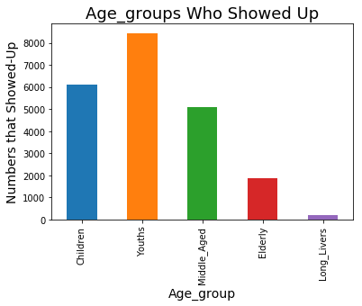

```python
# Create a bar chart(with defined function) that shows the Age_group with the most number that showed up for their appointment.

barchartFunction(Agegroup_show_count, 'Age_groups Who Showed Up', 'Age_group', 'Numbers that Showed-Up')
```

The Visualization of **Age_groups Who Showed Up** doesn't appear to be a fair comparison; as there's such a wide difference between the 'Showed-Up' number of every other _Age*group* and the Long_livers.

Let's make use of a histogram to check the *Age* distribution across the population sample. This will help tell if the the bar chart above makes a fair comparison of the numbers of each _Age*group* that showed up.

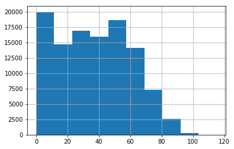

```python
# view histogram for _Age_ column in df

df.Age.hist()
```

To create a fair comparison, we find the proportion of each Age_group(that is, we divide each count of Age_group that showed up for their appointment by their total count in the original dataframe:

```python
# Calculate the total number found in each Age_group from the dataset, df

Agegroup_total = df.groupby('Age_group')['PatientID'].count()
Agegroup_total
```

```
Age_group
Children       26872
Youths         37174
Middle_Aged    29640
Elderly        12141
Long_Livers     1160
Name: PatientID, dtype: int64
```

```python
# proportion of Children who showed up for their appointments.

Children_proportion = Agegroup_show_count['Children'] / Agegroup_total['Children']
Children_proportion
```

```
0.22707651086632927
```

```python
# proportion of Youths who showed up for their appointments.

Youths_proportion = Agegroup_show_count['Youths'] / Agegroup_total['Youths']
Youths_proportion
```

```
0.22706730510571904
```

```python
# proportion of Middle_Aged who showed up for their appointments.

Middle_Aged_proportion = Agegroup_show_count['Middle_Aged'] / Agegroup_total['Middle_Aged']
Middle_Aged_proportion
```

```
0.17108636977058031
```

```python
# proportion of Elderly who showed up for their appointments

Elderly_proportion = Agegroup_show_count['Elderly'] / Agegroup_total['Elderly']
Elderly_proportion
```

```
0.15410592208220081
```

```python
# proportion of Long_Livers who showed up for their appointments.

Long_Livers_proportion = Agegroup_show_count['Long_Livers'] / Agegroup_total['Long_Livers']
Long_Livers_proportion
```

```
0.16810344827586207
```

## Visualization Showing the Different Proportion of Age_groups that Showed Up

```
Text(0,0.5,'Proportion that Showed-Up')
```

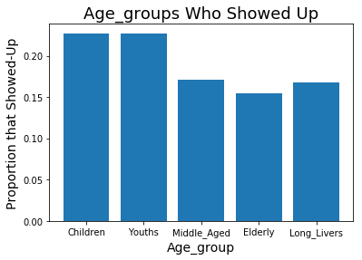

```python
# Create a bar chart showing the different proportion of Age_groups that showed up

Location = [1, 2, 3, 4, 5]
Height = [0.22707651086632927, 0.22706730510571904 , 0.17108636977058031, 0.15410592208220081, 0.16810344827586207]
label = ['Children', 'Youths', 'Middle_Aged', 'Elderly', 'Long_Livers']
plt.bar(Location, Height, tick_label=label)
plt.title('Age_groups Who Showed Up', fontsize=18)
plt.xlabel('Age_group', fontsize=14)
plt.ylabel('Proportion that Showed-Up', fontsize=14)
```

### Question 2 (Do patients under the Brazilian Scholarship show up for their appointment more than those who are not?)

From the **df_show** dataframe(which contains data for all patients who showed up for their appointment) created earlier, I am going to draw information about the number of patients under the Brazilian scholarship(and those who are not), who showed up for their appointments

```python
df_show.query('Scholarship == "1"').shape[0]
```

```
2578
```

```python
df_show.query('Scholarship == "0"').shape[0]
```

```
19741
```

```python
# Count of patients under the Brasilian scholarship and those who aren't

df_show_count = df_show.groupby('Scholarship')['No_show'].count()
df_show_count
```

```
Scholarship
0    19741
1     2578
Name: No_show, dtype: int64
```

Patients under the scholarship have the boolean result "1", while those who are not under the scholarship have the boolean result "0"

### Visualization for Recipients and Non-Recipients of The Brasilian Scholarship who Showed-Up

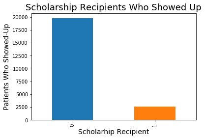

```python
# Create a bar chart to compare the number of recipients of the scholarship who showed up to that of the non-recipients who
# showed up

barchartFunction(df_show_count, 'Scholarship Recipients Who Showed Up', 'Scholarhip Recipient', 'Patients Who Showed-Up')
```

The bar chart above shows that the number of non-recipients of the scholarship(indicated by tick_label "0") who showed up for their appointment is about 17,000 more than scholarship recipients(indicated by tick_label "1") who showed up. This can be misleading in the sense that, out of a sample of patients of about 110,000, about 90% are patients who are not under the scholarship.

Therefore to make fair the comparison, we'll find the proportion of both recipients and non-recipients of the scholarship:

```python
# First, we find the dataframe of patients who did not show up for their appointment

df_noshow = df.query('No_show == "No"')
df_noshow
```

|  | PatientID | AppointmentID | Gender | ScheduledDay | AppointmentDay | Age | Neighbourhood | Scholarship | Hypertension | Diabetes | Alcoholism | Handicap | SMS_received | No_show | Age_group |
| --- | --- | --- | --- | --- | --- | --- | --- | --- | --- | --- | --- | --- | --- | --- | --- |
| 0 | 2.98724998243e+13 | 5642903 | F | 2016-04-29T18:38:08Z | 2016-04-29T00:00:00Z | 62 | JARDIM DA PENHA | 0 | 1 | 0 | 0 | 0 | 0 | No | Middle_Aged |
| 1 | 5.58997776694e+14 | 5642503 | M | 2016-04-29T16:08:27Z | 2016-04-29T00:00:00Z | 56 | JARDIM DA PENHA | 0 | 0 | 0 | 0 | 0 | 0 | No | Middle_Aged |
| 2 | 4.26296229995e+12 | 5642549 | F | 2016-04-29T16:19:04Z | 2016-04-29T00:00:00Z | 62 | MATA DA PRAIA | 0 | 0 | 0 | 0 | 0 | 0 | No | Middle_Aged |
| 3 | 867951213174.0 | 5642828 | F | 2016-04-29T17:29:31Z | 2016-04-29T00:00:00Z | 8 | PONTAL DE CAMBURI | 0 | 0 | 0 | 0 | 0 | 0 | No | Children |
| 4 | 8.84118644818e+12 | 5642494 | F | 2016-04-29T16:07:23Z | 2016-04-29T00:00:00Z | 56 | JARDIM DA PENHA | 0 | 1 | 1 | 0 | 0 | 0 | No | Middle_Aged |
| 5 | 9.59851332313e+13 | 5626772 | F | 2016-04-27T08:36:51Z | 2016-04-29T00:00:00Z | 76 | REPÚBLICA | 0 | 1 | 0 | 0 | 0 | 0 | No | Elderly |
| 8 | 5.639472995e+13 | 5638447 | F | 2016-04-29T08:02:16Z | 2016-04-29T00:00:00Z | 21 | ANDORINHAS | 0 | 0 | 0 | 0 | 0 | 0 | No | Youths |
| 9 | 7.81245643693e+13 | 5629123 | F | 2016-04-27T12:48:25Z | 2016-04-29T00:00:00Z | 19 | CONQUISTA | 0 | 0 | 0 | 0 | 0 | 0 | No | Children |
| 10 | 7.34536231958e+14 | 5630213 | F | 2016-04-27T14:58:11Z | 2016-04-29T00:00:00Z | 30 | NOVA PALESTINA | 0 | 0 | 0 | 0 | 0 | 0 | No | Youths |
| 12 | 5.66654781423e+14 | 5634718 | F | 2016-04-28T11:33:51Z | 2016-04-29T00:00:00Z | 22 | NOVA PALESTINA | 1 | 0 | 0 | 0 | 0 | 0 | No | Youths |
| 13 | 9.11394617216e+14 | 5636249 | M | 2016-04-28T14:52:07Z | 2016-04-29T00:00:00Z | 28 | NOVA PALESTINA | 0 | 0 | 0 | 0 | 0 | 0 | No | Youths |
| 14 | 9.98847233349e+13 | 5633951 | F | 2016-04-28T10:06:24Z | 2016-04-29T00:00:00Z | 54 | NOVA PALESTINA | 0 | 0 | 0 | 0 | 0 | 0 | No | Middle_Aged |
| 15 | 99948393975.0 | 5620206 | F | 2016-04-26T08:47:27Z | 2016-04-29T00:00:00Z | 15 | NOVA PALESTINA | 0 | 0 | 0 | 0 | 0 | 1 | No | Children |
| 16 | 8.45743929428e+13 | 5633121 | M | 2016-04-28T08:51:47Z | 2016-04-29T00:00:00Z | 50 | NOVA PALESTINA | 0 | 0 | 0 | 0 | 0 | 0 | No | Middle_Aged |
| 18 | 1.71353782452e+13 | 5621836 | F | 2016-04-26T10:54:18Z | 2016-04-29T00:00:00Z | 30 | NOVA PALESTINA | 1 | 0 | 0 | 0 | 0 | 1 | No | Youths |
| 19 | 7.22328918422e+12 | 5640433 | F | 2016-04-29T10:43:14Z | 2016-04-29T00:00:00Z | 46 | DA PENHA | 0 | 0 | 0 | 0 | 0 | 0 | No | Middle_Aged |
| 23 | 2.13753979426e+14 | 5634142 | F | 2016-04-28T10:27:05Z | 2016-04-29T00:00:00Z | 46 | CONQUISTA | 0 | 0 | 0 | 0 | 0 | 0 | No | Middle_Aged |
| 24 | 8.73485799688e+12 | 5641780 | F | 2016-04-29T14:19:19Z | 2016-04-29T00:00:00Z | 65 | TABUAZEIRO | 0 | 0 | 0 | 0 | 0 | 0 | No | Middle_Aged |
| 25 | 5.8193699788e+12 | 5624020 | M | 2016-04-26T15:04:17Z | 2016-04-29T00:00:00Z | 46 | CONQUISTA | 0 | 1 | 0 | 0 | 0 | 1 | No | Middle_Aged |
| 26 | 25787851512.0 | 5641781 | F | 2016-04-29T14:19:42Z | 2016-04-29T00:00:00Z | 45 | BENTO FERREIRA | 0 | 1 | 0 | 0 | 0 | 0 | No | Youths |
| 27 | 1.21548437528e+13 | 5628345 | F | 2016-04-27T10:51:45Z | 2016-04-29T00:00:00Z | 4 | CONQUISTA | 0 | 0 | 0 | 0 | 0 | 0 | No | Children |
| 28 | 5.92617169253e+12 | 5642400 | M | 2016-04-29T15:48:02Z | 2016-04-29T00:00:00Z | 51 | SÃO PEDRO | 0 | 0 | 0 | 0 | 0 | 0 | No | Middle_Aged |
| 29 | 1.22577616366e+12 | 5642186 | F | 2016-04-29T15:16:29Z | 2016-04-29T00:00:00Z | 32 | SANTA MARTHA | 0 | 0 | 0 | 0 | 0 | 0 | No | Youths |
| 30 | 342815551642.0 | 5628068 | F | 2016-04-27T10:24:52Z | 2016-04-29T00:00:00Z | 46 | NOVA PALESTINA | 0 | 0 | 0 | 0 | 0 | 0 | No | Middle_Aged |
| 32 | 5.28835627695e+13 | 5637908 | M | 2016-04-29T07:30:27Z | 2016-04-29T00:00:00Z | 61 | SÃO CRISTÓVÃO | 0 | 1 | 0 | 0 | 0 | 0 | No | Middle_Aged |
| 33 | 7.65351699971e+12 | 5616921 | F | 2016-04-25T15:01:04Z | 2016-04-29T00:00:00Z | 38 | SÃO CRISTÓVÃO | 1 | 0 | 0 | 0 | 0 | 1 | No | Youths |
| 34 | 1.9999756533e+13 | 5637963 | F | 2016-04-29T07:34:30Z | 2016-04-29T00:00:00Z | 79 | SÃO CRISTÓVÃO | 0 | 1 | 0 | 0 | 0 | 0 | No | Elderly |
| 35 | 7.81626351616e+13 | 5637968 | M | 2016-04-29T07:34:42Z | 2016-04-29T00:00:00Z | 18 | SÃO CRISTÓVÃO | 0 | 0 | 0 | 0 | 0 | 0 | No | Children |
| 36 | 7.29845876214e+13 | 5637975 | F | 2016-04-29T07:35:19Z | 2016-04-29T00:00:00Z | 63 | SÃO CRISTÓVÃO | 0 | 1 | 1 | 0 | 0 | 0 | No | Middle_Aged |
| 37 | 1.57813186174e+12 | 5637986 | F | 2016-04-29T07:35:56Z | 2016-04-29T00:00:00Z | 64 | TABUAZEIRO | 1 | 1 | 1 | 0 | 0 | 0 | No | Middle_Aged |
| ... | ... | ... | ... | ... | ... | ... | ... | ... | ... | ... | ... | ... | ... | ... | ... |
| 110494 | 2.89581673197e+14 | 5779073 | F | 2016-06-06T17:44:14Z | 2016-06-08T00:00:00Z | 38 | MARIA ORTIZ | 0 | 0 | 0 | 0 | 0 | 0 | No | Youths |
| 110495 | 7.49948894913e+12 | 5759838 | M | 2016-06-01T13:49:47Z | 2016-06-01T00:00:00Z | 40 | MARIA ORTIZ | 0 | 0 | 0 | 0 | 0 | 0 | No | Youths |
| 110497 | 7.93589177751e+14 | 5757745 | M | 2016-06-01T09:46:33Z | 2016-06-01T00:00:00Z | 76 | MARIA ORTIZ | 0 | 0 | 0 | 0 | 0 | 0 | No | Elderly |
| 110498 | 9.43365361457e+13 | 5787655 | F | 2016-06-08T10:21:14Z | 2016-06-08T00:00:00Z | 59 | MARIA ORTIZ | 0 | 0 | 0 | 0 | 0 | 0 | No | Middle_Aged |
| 110499 | 8.21969177626e+14 | 5757697 | F | 2016-06-01T09:42:56Z | 2016-06-01T00:00:00Z | 66 | MARIA ORTIZ | 0 | 1 | 1 | 0 | 0 | 0 | No | Elderly |
| 110500 | 4.43438443335e+14 | 5787233 | F | 2016-06-08T09:35:13Z | 2016-06-08T00:00:00Z | 59 | MARIA ORTIZ | 0 | 0 | 0 | 0 | 0 | 0 | No | Middle_Aged |
| 110501 | 454425189389.0 | 5758133 | M | 2016-06-01T10:19:12Z | 2016-06-01T00:00:00Z | 44 | MARIA ORTIZ | 0 | 0 | 0 | 0 | 0 | 0 | No | Youths |
| 110502 | 7.31622885365e+14 | 5787937 | F | 2016-06-08T10:50:42Z | 2016-06-08T00:00:00Z | 22 | GOIABEIRAS | 0 | 0 | 0 | 0 | 0 | 0 | No | Youths |
| 110503 | 2.36218168228e+13 | 5759473 | F | 2016-06-01T13:00:36Z | 2016-06-01T00:00:00Z | 64 | SOLON BORGES | 0 | 0 | 0 | 0 | 0 | 0 | No | Middle_Aged |
| 110504 | 9.94798255557e+12 | 5788052 | F | 2016-06-08T11:06:21Z | 2016-06-08T00:00:00Z | 4 | MARIA ORTIZ | 0 | 0 | 0 | 0 | 0 | 0 | No | Children |
| 110505 | 5.6673438856e+13 | 5758455 | F | 2016-06-01T10:45:50Z | 2016-06-01T00:00:00Z | 55 | MARIA ORTIZ | 0 | 0 | 0 | 0 | 0 | 0 | No | Middle_Aged |
| 110506 | 897388334326.0 | 5758779 | M | 2016-06-01T11:09:20Z | 2016-06-01T00:00:00Z | 5 | MARIA ORTIZ | 0 | 0 | 0 | 0 | 0 | 0 | No | Children |
| 110507 | 4.76946211847e+14 | 5786918 | F | 2016-06-08T09:04:18Z | 2016-06-08T00:00:00Z | 0 | MARIA ORTIZ | 0 | 0 | 0 | 0 | 0 | 0 | No | NaN |
| 110508 | 9.43365361457e+13 | 5757656 | F | 2016-06-01T09:41:00Z | 2016-06-01T00:00:00Z | 59 | MARIA ORTIZ | 0 | 0 | 0 | 0 | 0 | 0 | No | Middle_Aged |
| 110509 | 4.95296829376e+14 | 5786750 | M | 2016-06-08T08:50:51Z | 2016-06-08T00:00:00Z | 33 | MARIA ORTIZ | 0 | 0 | 0 | 0 | 0 | 0 | No | Youths |
| 110510 | 2.36218168228e+13 | 5757587 | F | 2016-06-01T09:35:48Z | 2016-06-01T00:00:00Z | 64 | SOLON BORGES | 0 | 0 | 0 | 0 | 0 | 0 | No | Middle_Aged |
| 110511 | 823599626588.0 | 5786742 | F | 2016-06-08T08:50:20Z | 2016-06-08T00:00:00Z | 14 | MARIA ORTIZ | 0 | 0 | 0 | 0 | 0 | 0 | No | Children |
| 110512 | 9.87624564474e+13 | 5786368 | F | 2016-06-08T08:20:01Z | 2016-06-08T00:00:00Z | 41 | MARIA ORTIZ | 0 | 0 | 0 | 0 | 0 | 0 | No | Youths |
| 110513 | 8.67477849953e+13 | 5785964 | M | 2016-06-08T07:52:55Z | 2016-06-08T00:00:00Z | 2 | ANTÔNIO HONÓRIO | 0 | 0 | 0 | 0 | 0 | 0 | No | Children |
| 110514 | 2.69568517714e+12 | 5786567 | F | 2016-06-08T08:35:31Z | 2016-06-08T00:00:00Z | 58 | MARIA ORTIZ | 0 | 0 | 0 | 0 | 0 | 0 | No | Middle_Aged |
| 110517 | 5.57494241893e+12 | 5780122 | F | 2016-06-07T07:38:34Z | 2016-06-07T00:00:00Z | 19 | MARIA ORTIZ | 0 | 0 | 0 | 0 | 0 | 0 | No | Children |
| 110518 | 7.26331492534e+13 | 5630375 | F | 2016-04-27T15:15:06Z | 2016-06-07T00:00:00Z | 50 | MARIA ORTIZ | 0 | 0 | 0 | 0 | 0 | 1 | No | Middle_Aged |
| 110519 | 6.54238778939e+13 | 5630447 | F | 2016-04-27T15:23:14Z | 2016-06-07T00:00:00Z | 22 | MARIA ORTIZ | 0 | 0 | 0 | 0 | 0 | 1 | No | Youths |
| 110520 | 9.96997666246e+14 | 5650534 | F | 2016-05-03T07:51:47Z | 2016-06-07T00:00:00Z | 42 | MARIA ORTIZ | 0 | 0 | 0 | 0 | 0 | 1 | No | Youths |
| 110521 | 3.63553377464e+13 | 5651072 | F | 2016-05-03T08:23:40Z | 2016-06-07T00:00:00Z | 53 | MARIA ORTIZ | 0 | 0 | 0 | 0 | 0 | 1 | No | Middle_Aged |
| 110522 | 2.57213436929e+12 | 5651768 | F | 2016-05-03T09:15:35Z | 2016-06-07T00:00:00Z | 56 | MARIA ORTIZ | 0 | 0 | 0 | 0 | 0 | 1 | No | Middle_Aged |
| 110523 | 3.59626632874e+12 | 5650093 | F | 2016-05-03T07:27:33Z | 2016-06-07T00:00:00Z | 51 | MARIA ORTIZ | 0 | 0 | 0 | 0 | 0 | 1 | No | Middle_Aged |
| 110524 | 1.55766317299e+13 | 5630692 | F | 2016-04-27T16:03:52Z | 2016-06-07T00:00:00Z | 21 | MARIA ORTIZ | 0 | 0 | 0 | 0 | 0 | 1 | No | Youths |
| 110525 | 9.21349314356e+13 | 5630323 | F | 2016-04-27T15:09:23Z | 2016-06-07T00:00:00Z | 38 | MARIA ORTIZ | 0 | 0 | 0 | 0 | 0 | 1 | No | Youths |
| 110526 | 3.77511518121e+14 | 5629448 | F | 2016-04-27T13:30:56Z | 2016-06-07T00:00:00Z | 54 | MARIA ORTIZ | 0 | 0 | 0 | 0 | 0 | 1 | No | Middle_Aged |

88207 rows × 15 columns

```python
# Next, we count the number of recipients and non-recipients of the scholarship using the groupby() and count() functions

df_noshow_count = df_noshow.groupby('Scholarship')['No_show'].count()
df_noshow_count
```

```
Scholarship
0    79924
1     8283
Name: No_show, dtype: int64
```

To get the proportion of scholarship recipients who showed up for their appointment and the proportion of non-recipients who showed up for their appointment:

First, we calculate the total number of non-recipients:

```python
# total number of patients without scholarship

total = df_show_count[0] + df_noshow_count[0]
total
```

```
99665
```

Next, we calculate the proportion of people who without a scholarship still showed up for their appointment

```python
# proportion of non-recipients who showed up for their appointment

no_scholarship_proportion = df_show_count[0] / total
no_scholarship_proportion
```

```
0.19807354638037425
```

Secondly, we calculate the total number of recipients:

```python
# total number of patients without scholarship

total_scholarship = df_show_count[1] + df_noshow_count[1]
total_scholarship
```

```
10861
```

Next, we calculate the proportion of people who are under the scholarship and showed up for their appointment

```python
# proportion of recipients who  showed up for their appointment

scholarship_proportion =  df_show_count[1] / total_scholarship
scholarship_proportion
```

```
0.23736304207715681
```

## Visualization for Question 2

```
Text(0,0.5,'Scholarship Proportion')
```

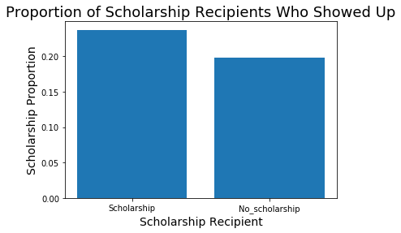

```python
# Create a bar_chart with proper labels showing the proportions of recipients and non-recipients of the scholarship who showed up

Scholarship = 0.237
No_scholarship = 0.198

Location = [1, 2]
Height = [0.237, 0.198]
label = ['Scholarship', 'No_scholarship']
plt.bar(Location, Height, tick_label=label)
plt.title('Proportion of Scholarship Recipients Who Showed Up', fontsize=18)
plt.xlabel('Scholarship Recipient', fontsize=14)
plt.ylabel('Scholarship Proportion', fontsize=14)
```

## Conclusions

> **Tip**: Finally, summarize your findings and the results that have been performed in relation to the question(s) provided at the beginning of the analysis. Summarize the results accurately, and point out where additional research can be done or where additional information could be useful.

```python
# number of unique PatientID

df.PatientID.nunique()
```

```
62298
```

```python
# number of unique AppointmentID

df.AppointmentID.nunique()
```

```
110526
```

```python
from subprocess import call
call(['python', '-m', 'nbconvert', 'Investigate_a_Dataset.ipynb'])
```

```
255
```